# Cemeteries and Life tables

Cody M Kent

February 4, 2019

# Cemetery Lab Data Analyis

## Introduction

1. This lab document goes with the provided R script that you will be working with
2. Before starting this lab you should have already created a csv file containing the demography data you collected. This will be done in class.
3. This csv file should be saved in a separate Data folder inside your Ecology Lab project and titled “Cemetery_Partial_NOLA_Data.csv”
4. You should have a second csv file titled Cemetery_Full_NOLA_Data.csv saved in the data folder
5. You should have a file titled CemeteryScript_Student.R that contains most of the script for today’s analysis

## Loading and examining data

First lets load in our that we collected in lab data file and check it for anything that doesn’t make sense. Use the same commands we used before, including `head`, `tail`,`str`, and `summary`.

```r
Nola<-read.csv('data/Cemetery_Partial_NOLA_Data.csv')
```

Everything look good? If so, lets move on.

## Organizing Data

For this lab we will be doing most of the analysis on the different sexes separately. Use the `subset.data.frame()` function to make different data frames for each of the sexes.

```r
NolaF<-subset.data.frame(Nola,Nola$Sex=='Female') #grab all of the females
NolaM<-subset.data.frame(Nola,Nola$Sex=='Male') #and grab all the males
```

## Paramaterize the life tables

We will now do a series of calculations to find the different values to populate our life tables. The formulas are provided in your lab manual and and an outline is provided here for you to follow. You will have to do it both for females and males.

### nx

First we will calculate nx, or the number alive at the start of each age group. We will be using a `for` loop here. Make sure you understand how the loop is working. The code is provided for females.

```r
NolaF$nx<-rep(NA) #create an empty placeholder for the data
NolaF$nx[1]<-sum(NolaF$dx) # the first value is easy
for(i in 2:(nrow(NolaF))){ #loop over each row
  NolaF$nx[i]<-NolaF$nx[i-1]-NolaF$dx[i-1] #calculate nx
}

#now you do it for males
```

### lx and qx

Next we will calculate sponsorship (lx) and age specific-mortality (qx). A rough framework is provided

```r
NolaF$lx<-  #insert the formula to calculate lx
NolaM$lx<-

NolaF$qx<-  #insert the formula for qx
NolaM$qx<-
```

Now lets take a quick look at our life tables to make sure everything looks OK

```r
NolaF
NolaM
```

There may be some `NaN`s generated. Why would this happen? Should this cause any problems?

## Generating Curves

Now that we have a life table, lets make some curves to help visualize the data.

### Survivorship curve

Here we will graph the survivorship of both sexes across age classes. Note that these graphs are typically log-transformed to identify the type of survivorhsip curve. Yours should look similar to the one below.

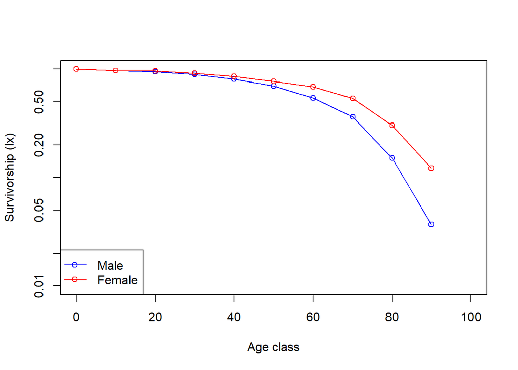

```r
plot(lx~AgeClass,data=NolaM, #plot the data
     type='o',col='blue', #make it be blue connected points
     ylim=c(0.01,1),log='y', #log transform the y axis
     ylab='Survivorship (lx)',xlab='Age class') #change the axis labels
points(lx~AgeClass,data=NolaF,type='o',col='red') #plot females
legend('bottomleft',legend=c('Male','Female'),lty=1,pch=1,col=c('blue','red')) #add legend
```

### Mortality curve

Now make a similar graph, but this time plot age-class specific mortality (qx). Also, we will not log-transform this graph. This time the code is not provided for you, but it should look similar to the one below

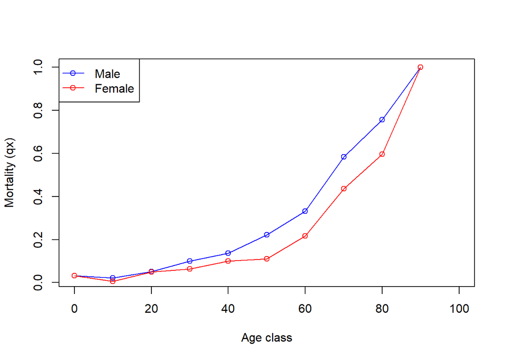

## Statistical tests

Now lets perform a statistical test to see if the two sexes differ in the number (frequency) of people that died in each age class. To do this we will be using a chi-square test. Remember, a chi-square test compares frequencies two categorical variables.

In this data set we have a lot of age classes. Doing a chi-square test on many categories can be difficult, so first we will combine them into larger categories to perform the test.

To do this we will use a function provided for you called `Rebin()`. This function takes three vectors. The first is a vector of the new categories for the data (NewBin), the second is the old categories for the data (OldBin), and the third is the frequencies from the old data (Freq). In this case, the frequencies we will be using are dx. Make sure you understand how this function works.

```r
#First creat a vector with our new age categories
Bins<-c(0,20,40,60,199)

#Next is the function for putting the data into new bins

Rebin<-function(NewBin,OldBin,Freq){
  NewFreq<-rep(NA,length(NewBin)) #create a placehold for the new frequencies
  for(i in 1:(length(NewBin)-1)){ #loop over each bin of the old data
    sub<-subset(Freq,OldBin>=NewBin[i] & OldBin<NewBin[i+1]) #decide wheather it gets added
    NewFreq[i]<-sum(sub) #add the ones that met the rule
  }
  return(NewFreq)
}

#Now, use the function to create a table of observed frequencies

Observed<-data.frame(Female=Rebin(), #fill in the formula to run the fucntion
                  Male=Rebin())
rownames(Observed)<-Bins #put on row labels to match the bins
Observed<-Observed[-5,] #get rid of the extra row
```

```r
Chisq=chisq.test()
```

Remember to look at both the expected and observed tables when interpreting the results. So, what did you find?

## Your Assigment

You should also have received two other data files. The first is one for the whole cemetery and the second is for a cemetery at a different location. For your paper you will compare the life tables from these two full cemetery data sets.

You will need to include:

1. Four chi-square tests
- NOLA males x NOLA females
- ____ males x ____ females
- ____ males x NOLA males
- ____ females x NOLA females
2. Four figures (curves)
- one for each statistical test
- Must include at least one sponsorship and 1 mortality curve
- Other than that, pick the one that shows what you want to show the best

You should be able to do this analysis by tweaking the code from today. Let me know if you get stuck.